# Phylogenetic tree maize root bacteria collection AMPO formation

Thoenen et al. AMPO formation

Lisa Thoenen, update by Christine Pestalozzi

2024-05-14

## Load and format input data

Input: *Metadata bacteria:* Database_MRB_isolates & database_raw, *Mapping results:* Mapping in 4 soils and feedback, *Phylogeny:* Tree computed from 16s sequences (Sanger). Remove tips without any experimental data

Focus only on strains with AMPO phenotype. So filter the database accordingly

Read in the 16 Tree. Remove tips of strains without AMPO phenotype.

## Abundance in greenhouse based on mapping of Thoenen et al PNAS 2023

Hu Feedback cumulative abundance per strain at a 99% similarity cutoff, greenhouse B73 WT

For getting the cumulative abundance of ASVs matching isolates, relative abundances of all ASVs that mapped with >99% similarity are summed at the level of the isolate. The mapping was done based on 16S Sanger sequences and taken from Thoenen et al 2023 PNAS.

## Fig 1d AMPO formers of MRB collection

The tree is annotated with the quantitative abundance data from mapping greenhouse root microbiome dataset (to B73 WT) and qualitative information on the AMPO formation on the outer ring.

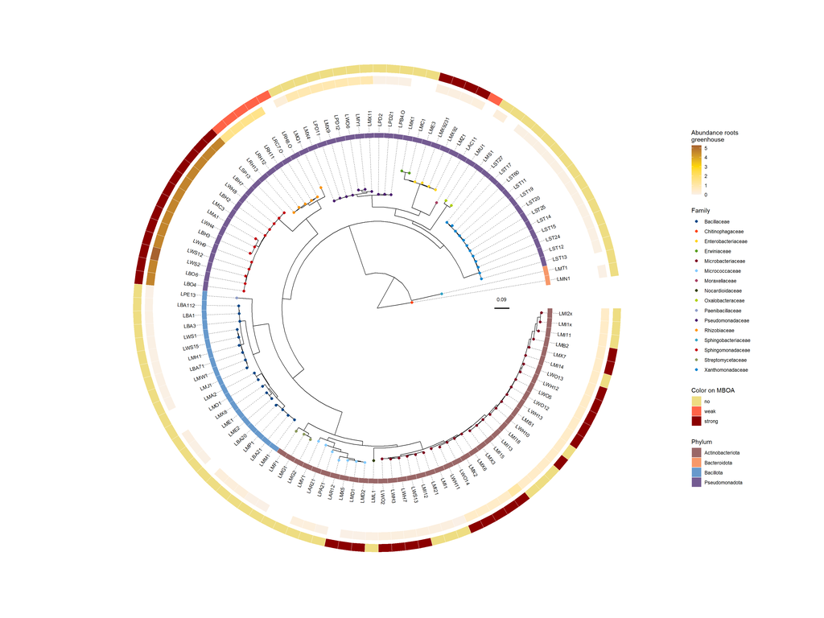

## Fig S4 Abundance of AMPO formers in microbiome of field data

Abundance of isolates from strain collection in microbiome datasets of the field and greenhouse. Mapping data and relative abundances of ASVs are taken from Thoenen et al 2023 PNAS.

Calculate cumulative abundance (after filtering of ASVs for combining) in greenhouse B73 WT (Hu Feedback, 2018)

Calculate cumulative abundance (after filtering of ASVs for combining) in field data for Changins, Reckenholz and Aurora (Cadot et al, 2021). Mappings taken from Thoenen et al 2023.

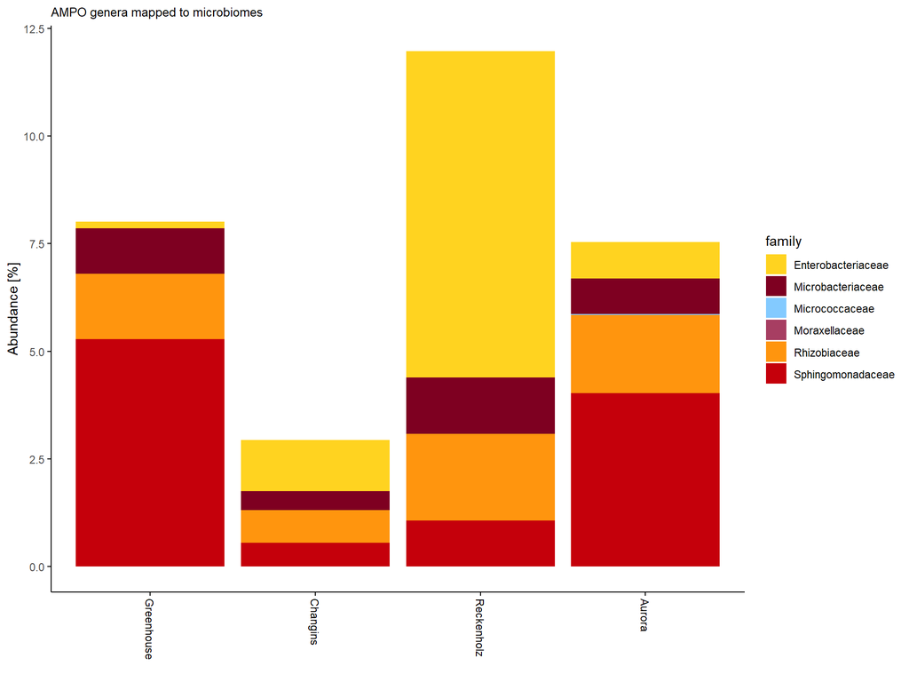

| phylum | family | location_background | compartment | cum_abundance |
| --- | --- | --- | --- | --- |
| Actinobacteria | Microbacteriaceae | Greenhouse_B73 | root | 1.0622718 |
| Actinobacteria | Micrococcaceae | Greenhouse_B73 | root | 0.0031003 |
| Proteobacteria | Enterobacteriaceae | Greenhouse_B73 | root | 0.1455602 |
| Proteobacteria | Rhizobiaceae | Greenhouse_B73 | root | 1.5174808 |
| Proteobacteria | Sphingomonadaceae | Greenhouse_B73 | root | 5.2770078 |
| Actinobacteria | Microbacteriaceae | Changins_B73 | root | 0.4478777 |
| Actinobacteria | Microbacteriaceae | Reckenholz_B73 | root | 1.3078915 |
| Actinobacteria | Microbacteriaceae | Aurora_W22 | root | 0.8313702 |
| Actinobacteria | Micrococcaceae | Changins_B73 | root | 0.0000000 |
| Actinobacteria | Micrococcaceae | Reckenholz_B73 | root | 0.0000000 |
| Actinobacteria | Micrococcaceae | Aurora_W22 | root | 0.0190287 |
| Proteobacteria | Enterobacteriaceae | Changins_B73 | root | 1.1816693 |
| Proteobacteria | Enterobacteriaceae | Reckenholz_B73 | root | 7.5826741 |
| Proteobacteria | Enterobacteriaceae | Aurora_W22 | root | 0.8477934 |
| Proteobacteria | Moraxellaceae | Changins_B73 | root | 0.0000000 |
| Proteobacteria | Moraxellaceae | Reckenholz_B73 | root | 0.0000000 |
| Proteobacteria | Moraxellaceae | Aurora_W22 | root | 0.0033512 |
| Proteobacteria | Rhizobiaceae | Changins_B73 | root | 0.7514671 |
| Proteobacteria | Rhizobiaceae | Reckenholz_B73 | root | 2.0131609 |
| Proteobacteria | Rhizobiaceae | Aurora_W22 | root | 1.8072787 |
| Proteobacteria | Sphingomonadaceae | Changins_B73 | root | 0.5543911 |
| Proteobacteria | Sphingomonadaceae | Reckenholz_B73 | root | 1.0640981 |
| Proteobacteria | Sphingomonadaceae | Aurora_W22 | root | 4.0310784 |

| Location | genotype | cumulative_abundance |
| --- | --- | --- |
| Greenhouse | B73 | 8.005421 |
| Changins | B73 | 2.935405 |
| Reckenholz | B73 | 11.967825 |
| Aurora | W22 | 7.539901 |

number of strains tested and number of AMPO formers

| Phylum | Class | Order | Family | Genus | Morphology_MBOA | n() |
| --- | --- | --- | --- | --- | --- | --- |
| Actinobacteria | Actinobacteria | Micrococcales | Microbacteriaceae | Micrococcineae | NR | 6 |
| Actinobacteria | Actinobacteria | Micrococcales | Microbacteriaceae | Micrococcineae | Red | 2 |
| Actinobacteria | Actinobacteria | Micrococcales | Micrococcaceae | Kocuria | NR | 1 |
| Actinobacteria | Actinobacteria | Micrococcales | Micrococcaceae | Pseudarthrobacter | Red | 1 |
| Actinobacteria | Actinobacteria | Propionibacteriales | Nocardioidaceae | Nocardioides | NR | 1 |
| Actinobacteria | Actinobacteria | Streptomycetales | Streptomycetaceae | Streptomyces | NR | 3 |
| Actinobacteriota | Actinobacteria | Actinomycetales | Microbacteriaceae | Micrococcineae | NR | 1 |
| Actinobacteriota | Actinobacteria | Actinomycetales | Micrococcaceae | Arthrobacter | NR | 1 |
| Actinobacteriota | Actinobacteria | Actinomycetales | Micrococcaceae | Paenarthrobacter | NR | 1 |
| Actinobacteriota | Actinobacteria | Micrococcales | Microbacteriaceae | Microbacterium | NR | 4 |
| Actinobacteriota | Actinobacteria | Micrococcales | Microbacteriaceae | Microbacterium | Red | 14 |
| Actinobacteriota | Actinobacteria | Micrococcales | Microbacteriaceae | Micrococcineae | Red | 1 |
| Actinobacteriota | Actinobacteria | Micrococcales | Micrococcaceae | Paenarthrobacter | NR | 1 |
| Actinobacteriota | Actinobacteria | Micrococcales | Micrococcaceae | Pseudarthrobacter | Red | 2 |
| Bacteroidetes | Bacteroidota | Bacteroidia | Chitinophagales | Chitinophaga | NR | 1 |
| Bacteroidota | Bacteroidia | Sphingobacteriales | Sphingobacteriaceae | Pedobacter | NR | 1 |
| Firmicutes | Bacilli | Bacillales | Bacillaceae | Bacillus | NR | 18 |
| Firmicutes | Bacilli | Paenibacillales | Paenibacillaceae | Paenibacillus | NR | 1 |
| Proteobacteria | Alphaproteobacteria | Rhizobiales | Rhizobiaceae | Allorhizobium-Neorhizobium-Pararhizobium-Rhizobium | pale_red | 1 |
| Proteobacteria | Alphaproteobacteria | Rhizobiales | Rhizobiaceae | Rhizobium | NR | 1 |
| Proteobacteria | Alphaproteobacteria | Rhizobiales | Rhizobiaceae | Rhizobium | pale_red | 4 |
| Proteobacteria | Alphaproteobacteria | Sphingomonadales | Sphingomonadaceae | Sphingobium | Red | 13 |
| Proteobacteria | Gammaproteobacteria | Burkholderiales | Oxalobacteraceae | Burkholderia | NR | 1 |
| Proteobacteria | Gammaproteobacteria | Burkholderiales | Oxalobacteraceae | Massilia | NR | 1 |
| Proteobacteria | Gammaproteobacteria | Enterobacterales | Enterobacteriaceae | Enterobacter | Red | 4 |
| Proteobacteria | Gammaproteobacteria | Enterobacterales | Erwiniaceae | Pantoea | NR | 2 |
| Proteobacteria | Gammaproteobacteria | Pseudomonadales | Moraxellaceae | Moraxellaceae | pale_red | 1 |
| Proteobacteria | Gammaproteobacteria | Pseudomonadales | Pseudomonadaceae | Pseudomonas | NR | 10 |
| Proteobacteria | Gammaproteobacteria | Xanthomonadales | Xanthomonadaceae | Stenotrophomonas | NR | 12 |